# Latin Square Design

STA6246 - DOE

Author

Dr. Cohen

## Introduction

- The Latin Square Design (LSD) allows us to eliminate two nuisance factors (blocking).
- Each factor has p levels
- We can control the effect of these blocking factors by grouping the experimental units into blocks.
- We consider a square wit p rows and p columns.

We can geenrate latin square in R as follows:

```r
library(magic)
# generate r by r latin square design
rlatin(5)
```

```
     [,1] [,2] [,3] [,4] [,5]
[1,]    4    2    1    5    3
[2,]    5    1    3    2    4
[3,]    1    5    4    3    2
[4,]    3    4    2    1    5
[5,]    2    3    5    4    1
```

## Rocket Propellant Experiment

- An experimenter wanted to study the effects of 5 different formulations of a rocket propellant on the observed burning rate.
- Each formulation is mixed from a batch of raw material.
- Each formulation is prepared by one operator for each batch.
- $p=5$ levels for each factor

$p^2= 25$ runs or observations.

### Data description

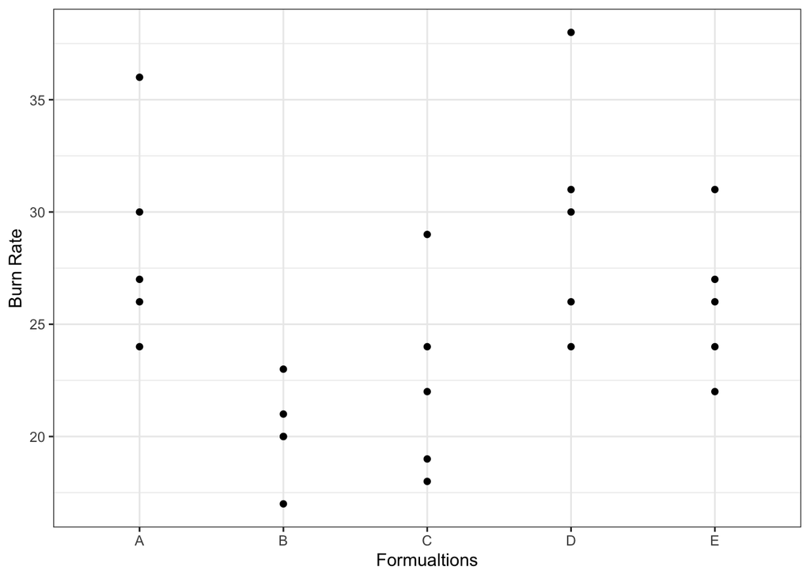

```r
library(tidyverse)
library(gtsummary)
# enter ER
BurnRate=c(24,17,18,26,22,20,24,38,31,30,19,30,26,26,20,24,27,27,23,29,24,36,21,22,31)
Bt=gl(n = 5, k = 1,length = 25, labels = c(1:5))
Op=gl(n = 5, k = 5,length = 25, labels = c(1:5))
Trts=c("A","B","C","D","E",
       "B","C","D","E","A",
       "C","D","E","A","B",
       "D","E","A","B","C",
       "E","A","B","C","D")

rocket=tibble(BurnRate,Bt,Op,Trts)

rocket %>%
  ggplot(aes(x=Trts,y=BurnRate)) +
  geom_point()+
  theme_bw()+
  labs(x="Formualtions",
       y="Burn Rate")
```

```r
rocket %>%
  tbl_summary(by=Trts)
```

| **Characteristic** | **A**, N = 5<sup>1</sup> | **B**, N = 5<sup>1</sup> | **C**, N = 5<sup>1</sup> | **D**, N = 5<sup>1</sup> | **E**, N = 5<sup>1</sup> |
| --- | --- | --- | --- | --- | --- |
| BurnRate | 27.0 (26.0, 30.0) | 20.0 (20.0, 21.0) | 22.0 (19.0, 24.0) | 30.0 (26.0, 31.0) | 26.0 (24.0, 27.0) |
| Bt |  |  |  |  |  |
| 1 | 1 (20%) | 1 (20%) | 1 (20%) | 1 (20%) | 1 (20%) |
| 2 | 1 (20%) | 1 (20%) | 1 (20%) | 1 (20%) | 1 (20%) |
| 3 | 1 (20%) | 1 (20%) | 1 (20%) | 1 (20%) | 1 (20%) |
| 4 | 1 (20%) | 1 (20%) | 1 (20%) | 1 (20%) | 1 (20%) |
| 5 | 1 (20%) | 1 (20%) | 1 (20%) | 1 (20%) | 1 (20%) |
| Op |  |  |  |  |  |
| 1 | 1 (20%) | 1 (20%) | 1 (20%) | 1 (20%) | 1 (20%) |
| 2 | 1 (20%) | 1 (20%) | 1 (20%) | 1 (20%) | 1 (20%) |
| 3 | 1 (20%) | 1 (20%) | 1 (20%) | 1 (20%) | 1 (20%) |
| 4 | 1 (20%) | 1 (20%) | 1 (20%) | 1 (20%) | 1 (20%) |
| 5 | 1 (20%) | 1 (20%) | 1 (20%) | 1 (20%) | 1 (20%) |

<sup>1</sup> Median (IQR); n (%)

- The formulations seem to impact the burnig rate
- The variability seems to be similar across the formulations

### ANOVA in R

##### Fitting

```r
library(sjPlot)

# ANOVA one factor and one blocking factor
results = aov(BurnRate ~ Trts + Bt + Op - 1 ,data = rocket)
summary(results)
```

```
          Df Sum Sq Mean Sq F value   Pr(>F)
Trts       5  16459    3292 308.606 3.07e-12 ***
Bt         4     68      17   1.594   0.2391
Op         4    150      38   3.516   0.0404 *
Residuals 12    128      11
---
Signif. codes:  0 '***' 0.001 '**' 0.01 '*' 0.05 '.' 0.1 ' ' 1
```

```r
tab_model(results)
```

|  | BurnRate |
| --- | --- |
| Predictors | p |
| Trts | **<0.001** |
| Bt | 0.239 |
| Op | **0.040** |
| Residuals |  |
| Observations | 25 |
| R<sup>2</sup> / R<sup>2</sup> adjusted | 0.992 / 0.984 |

```r
# Individual CIs - need to add the CI for the reference level
confint(results)
```

```
            2.5 %    97.5 %
TrtsA 16.26859896 26.531401
TrtsB  7.86859896 18.131401
TrtsC 10.06859896 20.331401
TrtsD 17.46859896 27.731401
TrtsE 13.66859896 23.931401
Bt2    0.09946357  9.100536
Bt3   -0.70053643  8.300536
Bt4   -1.10053643  7.900536
Bt5   -0.30053643  8.700536
Op2    2.69946357 11.700536
Op3   -1.70053643  7.300536
Op4    0.09946357  9.100536
Op5    0.89946357  9.900536
```

##### Model Adequacy

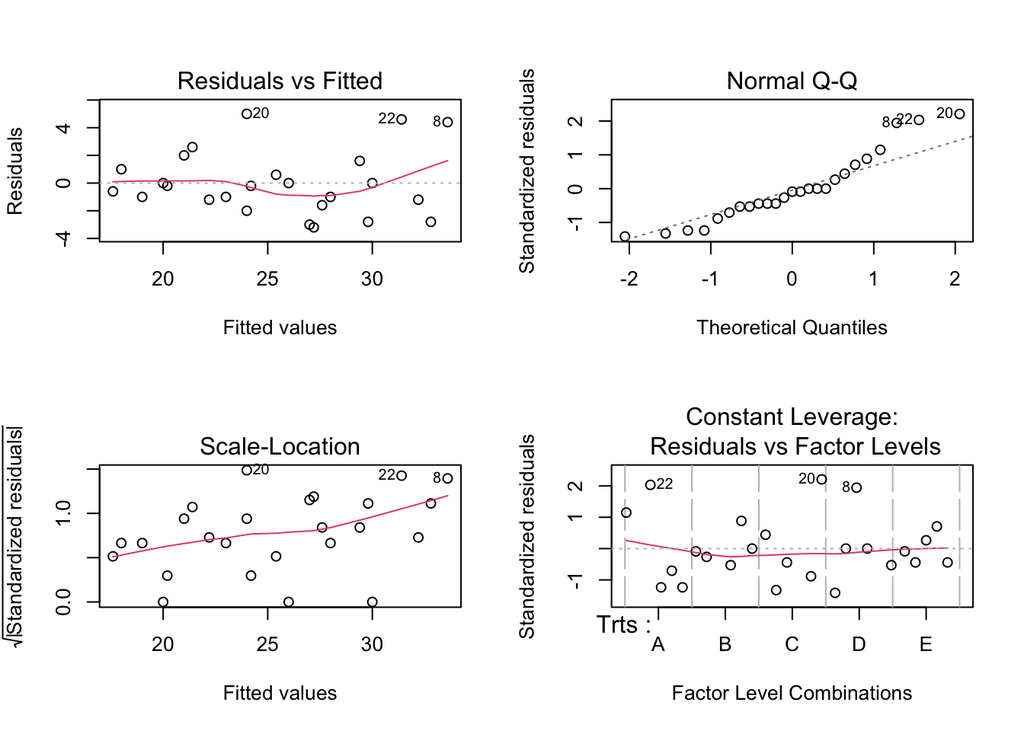

```r
par(mfrow=c(2,2))
plot(results)
```

We could consider a transformation because the Scale-Location plots is showing a trend.

##### Transformation

```r
library(car)
l=powerTransform(results)
l$roundlam
```

```
Y1
 0
```

```r
Tburn =log(BurnRate)
rano=aov(Tburn ~ Bt + Op + Trts)
summary(rano)
```

```
            Df Sum Sq Mean Sq F value   Pr(>F)
Bt           4 0.0933 0.02333   1.766 0.200512
Op           4 0.2316 0.05789   4.382 0.020557 *
Trts         4 0.5301 0.13252  10.030 0.000837 ***
Residuals   12 0.1586 0.01321
---
Signif. codes:  0 '***' 0.001 '**' 0.01 '*' 0.05 '.' 0.1 ' ' 1
```

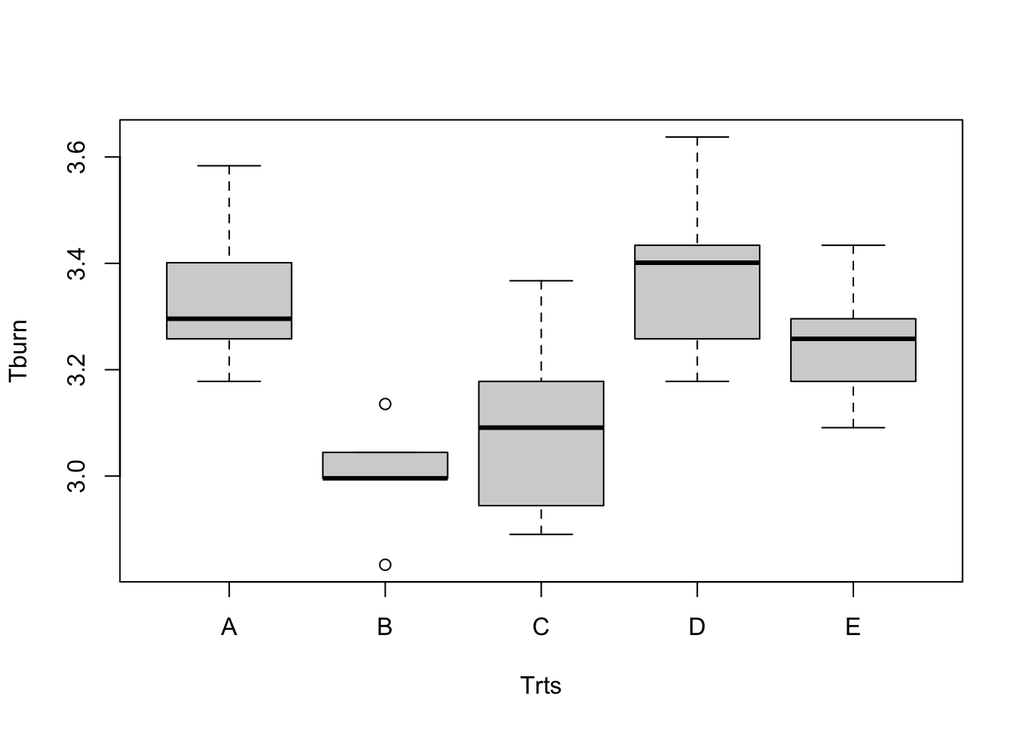

```r
boxplot(Tburn~Trts)
```

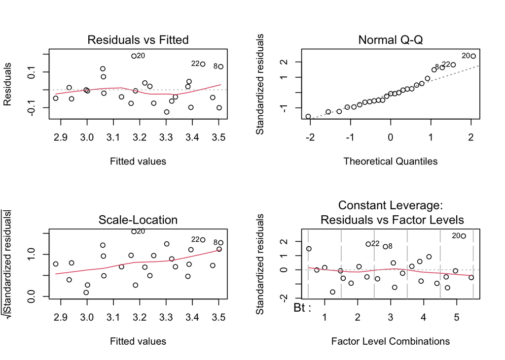

```r
par(mfrow=c(2,2))
plot(rano)
```

##### Multiple Comparison

Considering 5% level of significance.

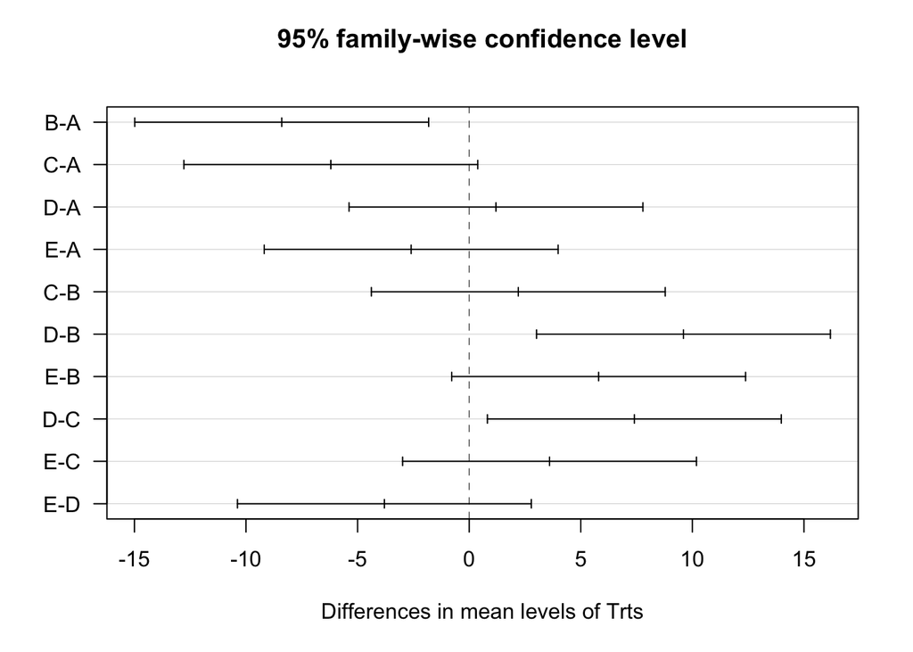

```r
#Tukey Test
THSD=TukeyHSD(results,which = "Trts")
plot(THSD,las=1)
```

```r
# Fisher LSD Test
library(agricolae)
L=LSD.test(results,"Trts",console=TRUE,group = F)
```

```
Study: results ~ "Trts"

LSD t Test for BurnRate

Mean Square Error:  10.66667

Trts,  means and individual ( 95 %) CI

  BurnRate      std r      LCL      UCL Min Max
A     28.6 4.669047 5 25.41764 31.78236  24  36
B     20.2 2.167948 5 17.01764 23.38236  17  23
C     22.4 4.393177 5 19.21764 25.58236  18  29
D     29.8 5.403702 5 26.61764 32.98236  24  38
E     26.0 3.391165 5 22.81764 29.18236  22  31

Alpha: 0.05 ; DF Error: 12
Critical Value of t: 2.178813

Comparison between treatments means

      difference pvalue signif.         LCL        UCL
A - B        8.4 0.0016      **   3.8994636 12.9005364
A - C        6.2 0.0110       *   1.6994636 10.7005364
A - D       -1.2 0.5720          -5.7005364  3.3005364
A - E        2.6 0.2321          -1.9005364  7.1005364
B - C       -2.2 0.3078          -6.7005364  2.3005364
B - D       -9.6 0.0006     *** -14.1005364 -5.0994636
B - E       -5.8 0.0158       * -10.3005364 -1.2994636
C - D       -7.4 0.0038      ** -11.9005364 -2.8994636
C - E       -3.6 0.1069          -8.1005364  0.9005364
D - E        3.8 0.0907       .  -0.7005364  8.3005364
```

**Conclusion**:

Formation D led to the higher mean burning rate and it is statistical significant different from formation C (p=0.025; 95% CI 0.82 to 14) and B (p=0.004; 95% CI 3.016 to 16.18).